# TourismProject

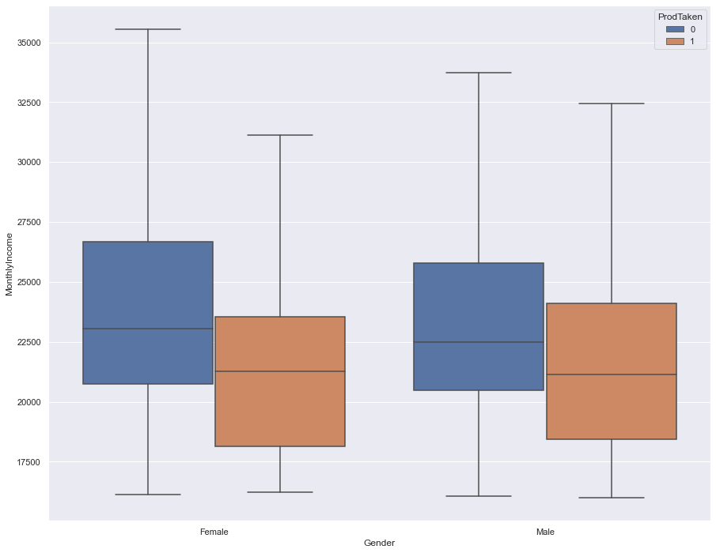

```python
# lets see how working hours per week vary across different occupation
plt.figure(figsize=(15,12))
sns.boxplot(y="MonthlyIncome", x="Gender", data=tourismdataDF,hue='ProdTaken',showfliers=False);
```

- Income range for males taking the product is higher than females

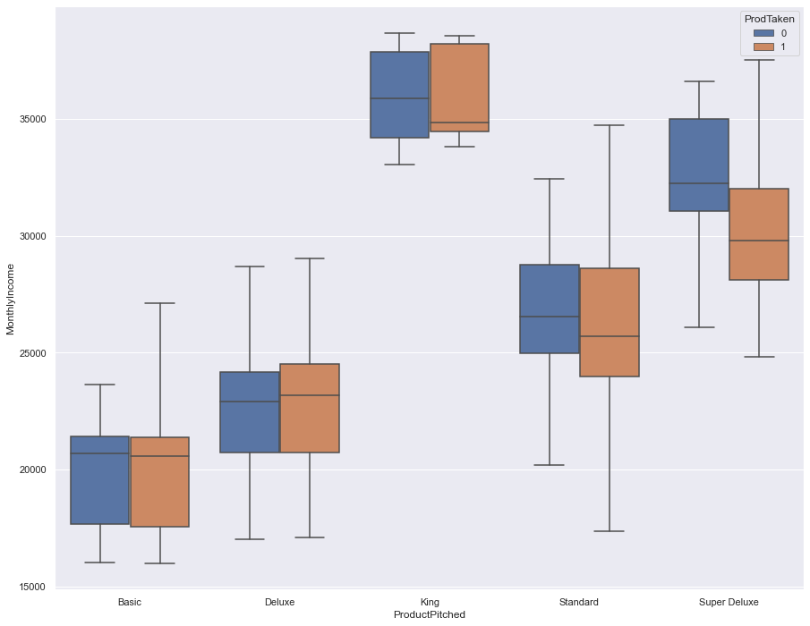

```python
# lets see how working hours per week vary across different occupation
plt.figure(figsize=(15,12))
sns.boxplot(y="MonthlyIncome", x="ProductPitched", data=tourismdataDF,hue='ProdTaken',showfliers=False);
```

- King Product was taken by the highest income range people followed by super deluxe
- Basic product was taken by lowest income range customers

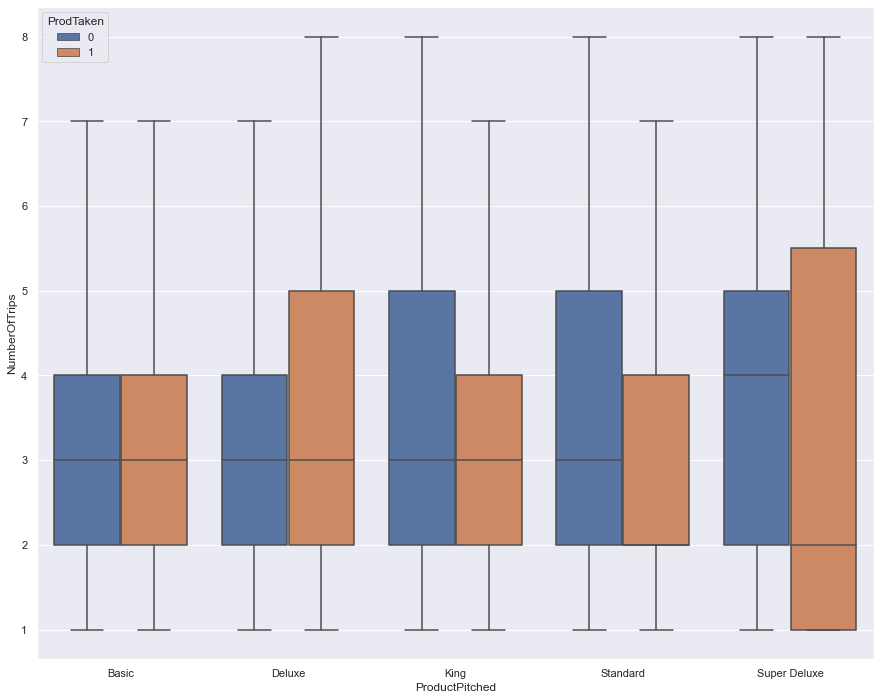

```python
# lets see how working hours per week vary across different occupation
plt.figure(figsize=(15,12))
sns.boxplot(y="NumberOfTrips", x="ProductPitched", data=tourismdataDF,hue='ProdTaken',showfliers=False);
```

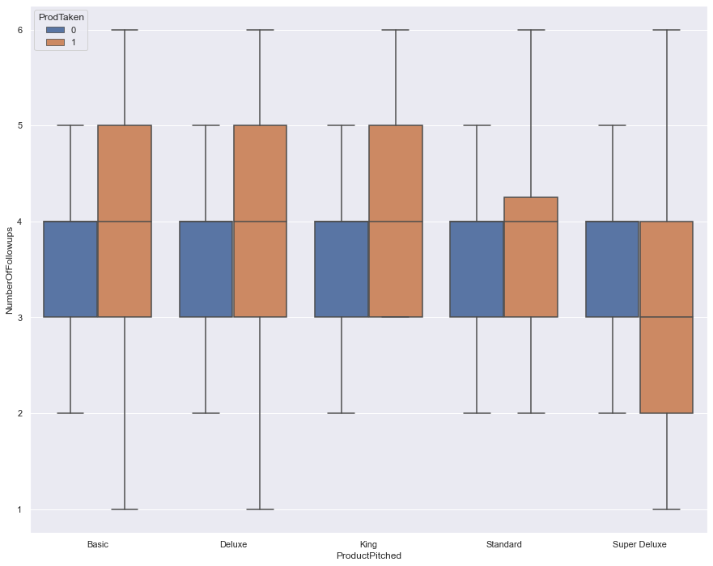

```python
# lets see how working hours per week vary across different occupation
plt.figure(figsize=(15,12))
sns.boxplot(y="NumberOfFollowups", x="ProductPitched", data=tourismdataDF,hue='ProdTaken',showfliers=False);
```

- 25% of the customers required till 2 follow ups for Super Deluxe product
- For rest fo the products 75% of the customers required atleast 3 followups

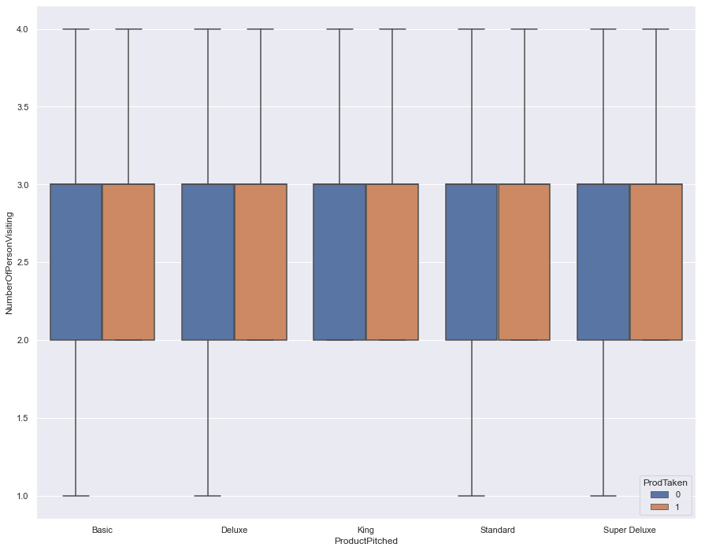

```python
# lets see how working hours per week vary across different occupation
plt.figure(figsize=(15,12))
sns.boxplot(y="NumberOfPersonVisiting", x="ProductPitched", data=tourismdataDF,hue='ProdTaken',showfliers=False);
```

- 50% of the people for each product who took the product made trips with 2-3 people.

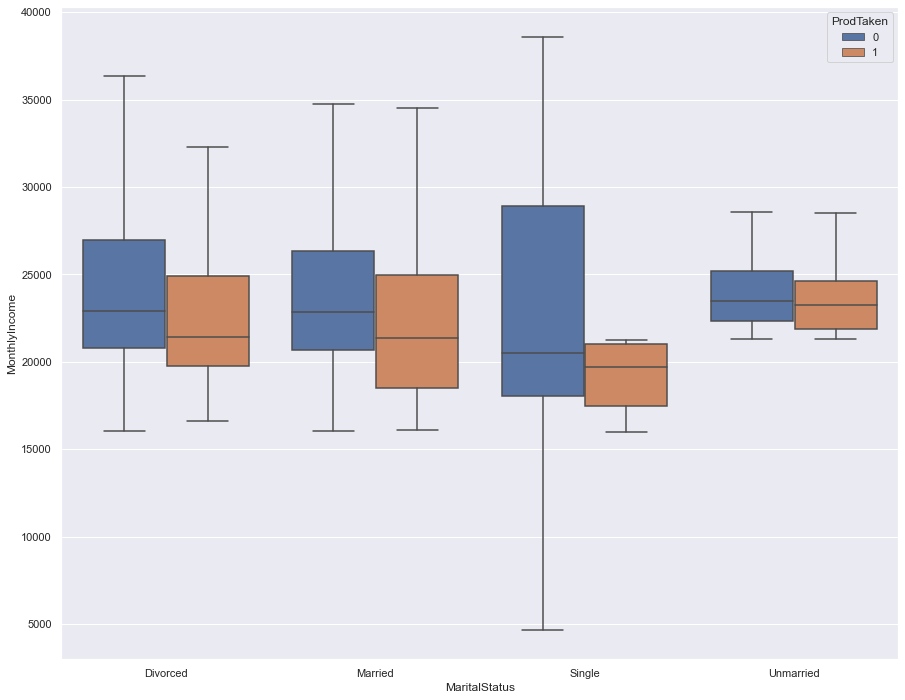

```python
# lets see how working hours per week vary across different occupation
plt.figure(figsize=(15,12))
sns.boxplot(y="MonthlyIncome", x="MaritalStatus", data=tourismdataDF,hue='ProdTaken',showfliers=False);
```

## Missing Value Treatment

```python
tourismdataDF.isnull().sum().sort_values(ascending=False)
```

```
DurationOfPitch             251
MonthlyIncome               233
Age                         226
NumberOfTrips               140
NumberOfChildrenVisiting     66
NumberOfFollowups            45
PreferredPropertyStar        26
TypeofContact                25
Gender                        0
CityTier                      0
Occupation                    0
ProductPitched                0
NumberOfPersonVisiting        0
Designation                   0
MaritalStatus                 0
Passport                      0
PitchSatisfactionScore        0
OwnCar                        0
ProdTaken                     0
dtype: int64
```

```python
print(tourismdataDF['DurationOfPitch'].isnull().sum())
tourismdataDF['DurationOfPitch'].fillna(tourismdataDF['DurationOfPitch'].mean(), inplace=True)  # mean imputation
tourismdataDF['DurationOfPitch'].isnull().sum()
```

```
251
```

```
0
```

- Put in the mean for Duration of Pitch

```python
tourismdataDF['TypeofContact'].mode()
```

```
0    Self Enquiry
Name: TypeofContact, dtype: category
Categories (2, object): ['Company Invited', 'Self Enquiry']
```

```python
tourismdataDF['TypeofContact'].value_counts()
```

```
Self Enquiry       3444
Company Invited    1419
Name: TypeofContact, dtype: int64
```

```python
print(tourismdataDF['TypeofContact'].isnull().sum())
tourismdataDF['TypeofContact'].fillna("Self Enquiry", inplace=True)
tourismdataDF['TypeofContact'].isnull().sum()
```

```
25
```

```
0
```

- Put in the mode for the type of contact

```python
tourismdataDF['PreferredPropertyStar'].value_counts()
```

```
3.0    2993
5.0     956
4.0     913
Name: PreferredPropertyStar, dtype: int64
```

For null values for PreferedPropertyStar putting the mode of the rest of the values

```python
print(tourismdataDF['PreferredPropertyStar'].isnull().sum())
tourismdataDF['PreferredPropertyStar'].fillna(3.0, inplace=True)
tourismdataDF['PreferredPropertyStar'].isnull().sum()
```

```
26
```

```
0
```

- Put in the mode for Prefered Property star

```python
print(tourismdataDF['MonthlyIncome'].isnull().sum())
tourismdataDF['MonthlyIncome'].fillna(tourismdataDF['MonthlyIncome'].mean(), inplace=True)  # mean imputation
tourismdataDF['MonthlyIncome'].isnull().sum()
```

```
233
```

```
0
```

- Put in the mean value for monthly income

```python
print(tourismdataDF.Age.value_counts())
```

```
35.0    237
36.0    231
34.0    211
31.0    203
30.0    199
32.0    197
33.0    189
37.0    185
29.0    178
38.0    176
41.0    155
39.0    150
28.0    147
40.0    146
42.0    142
27.0    138
43.0    130
46.0    121
45.0    116
26.0    106
44.0    105
51.0     90
47.0     88
50.0     86
25.0     74
52.0     68
53.0     66
48.0     65
49.0     65
55.0     64
54.0     61
56.0     58
24.0     56
22.0     46
23.0     46
59.0     44
21.0     41
20.0     38
19.0     32
58.0     31
60.0     29
57.0     29
18.0     14
61.0      9
Name: Age, dtype: int64
```

```python
print(tourismdataDF['Age'].isnull().sum())
tourismdataDF['Age'].fillna(math.floor(tourismdataDF['Age'].mean()), inplace=True)  # mean imputation
tourismdataDF['Age'].isnull().sum()
```

```
226
```

```
0
```

- Put in the mean for Age

```python
print(tourismdataDF.NumberOfTrips.value_counts())
```

```
2.0     1464
3.0     1079
1.0      620
4.0      478
5.0      458
6.0      322
7.0      218
8.0      105
21.0       1
19.0       1
22.0       1
20.0       1
Name: NumberOfTrips, dtype: int64
```

```python
print(tourismdataDF['NumberOfTrips'].isnull().sum())
tourismdataDF['NumberOfTrips'].fillna(2.0, inplace=True)  # mean imputation
tourismdataDF['NumberOfTrips'].isnull().sum()
```

```
140
```

```
0
```

- Put in the mode for number of trips

```python
print(tourismdataDF['NumberOfFollowups'].isnull().sum())
tourismdataDF['NumberOfFollowups'].fillna(statistics.mode(tourismdataDF['NumberOfFollowups']), inplace=True)  # mean imputation
tourismdataDF['NumberOfFollowups'].isnull().sum()
```

```
45
```

```
0
```

- Put in the mode for number of followups

```python
print(tourismdataDF['NumberOfChildrenVisiting'].isnull().sum())
tourismdataDF['NumberOfChildrenVisiting'].fillna(statistics.mode(tourismdataDF['NumberOfChildrenVisiting']), inplace=True)  # mean imputation
tourismdataDF['NumberOfChildrenVisiting'].isnull().sum()
```

```
66
```

```
0
```

- Put in the mode for number of children visiting

```python
tourismdataDF.isnull().sum().sort_values(ascending=False)
```

```
MonthlyIncome               0
NumberOfFollowups           0
Age                         0
TypeofContact               0
CityTier                    0
DurationOfPitch             0
Occupation                  0
Gender                      0
NumberOfPersonVisiting      0
ProductPitched              0
Designation                 0
PreferredPropertyStar       0
MaritalStatus               0
NumberOfTrips               0
Passport                    0
PitchSatisfactionScore      0
OwnCar                      0
NumberOfChildrenVisiting    0
ProdTaken                   0
dtype: int64
```

```python
tourismdataDF.info()
```

```
<class 'pandas.core.frame.DataFrame'>
RangeIndex: 4888 entries, 0 to 4887
Data columns (total 19 columns):
 #   Column                    Non-Null Count  Dtype
---  ------                    --------------  -----
 0   ProdTaken                 4888 non-null   int64
 1   Age                       4888 non-null   float64
 2   TypeofContact             4888 non-null   category
 3   CityTier                  4888 non-null   int64
 4   DurationOfPitch           4888 non-null   float64
 5   Occupation                4888 non-null   category
 6   Gender                    4888 non-null   category
 7   NumberOfPersonVisiting    4888 non-null   int64
 8   NumberOfFollowups         4888 non-null   float64
 9   ProductPitched            4888 non-null   category
 10  PreferredPropertyStar     4888 non-null   float64
 11  MaritalStatus             4888 non-null   category
 12  NumberOfTrips             4888 non-null   float64
 13  Passport                  4888 non-null   int64
 14  PitchSatisfactionScore    4888 non-null   int64
 15  OwnCar                    4888 non-null   int64
 16  NumberOfChildrenVisiting  4888 non-null   float64
 17  Designation               4888 non-null   category
 18  MonthlyIncome             4888 non-null   float64
dtypes: category(6), float64(7), int64(6)
memory usage: 526.2 KB
```

### Detecting Outliers

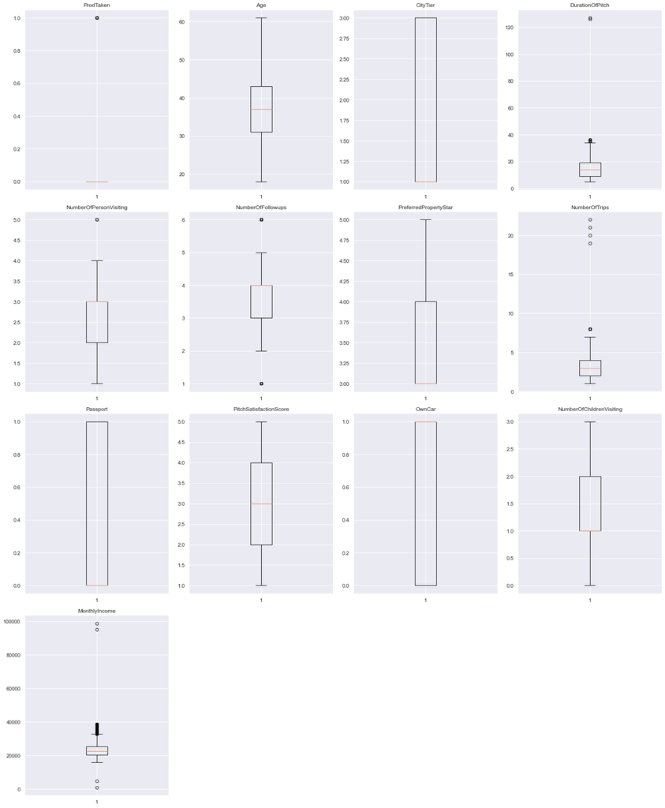

```python
# outlier detection using boxplot
numerical_col = tourismdataDF.select_dtypes(include=np.number).columns.tolist()
plt.figure(figsize=(20,30))

for i, variable in enumerate(numerical_col):
                     plt.subplot(5,4,i+1)
                     plt.boxplot(tourismdataDF[variable],whis=1.5)
                     plt.tight_layout()
                     plt.title(variable)

plt.show()
```

- Treating outliers as they have a potential to skew the models
- There are relatively few outliers in the data but still it will be good idea to treat them by updating the values smaller than lower whisker to the lower whisker value and updating the values greater than upper whisker to the upper whisker value

```python
def treat_outliers(data,col):
    '''
    treats outliers in a varaible
    col: str, name of the numerical varaible
    data: data frame
    col: name of the column
    '''
    Q1=data[col].quantile(0.25) # 25th quantile
    Q3=data[col].quantile(0.75)  # 75th quantile
    IQR=Q3-Q1
    Lower_Whisker = Q1 - 1.5*IQR
    Upper_Whisker = Q3 + 1.5*IQR
    data[col] = np.clip(data[col], Lower_Whisker, Upper_Whisker) # all the values smaller than Lower_Whisker will be assigned value of Lower_whisker
                                                            # and all the values above upper_whisker will be assigned value of upper_Whisker
    return data

def treat_outliers_all(data, col_list):
    '''
    treat outlier in all numerical varaibles
    col_list: list of numerical varaibles
    data: data frame
    '''
    for c in col_list:
        data = treat_outliers(data,c)

    return data
```

```python
numerical_col = tourismdataDF.select_dtypes(include=np.number).columns.tolist()# getting list of numerical columns


# items to be removed
treating= {'NumberOfFollowups', 'DurationOfPitch','MonthlyIncome'} # these column have very few non zero observation , doing outlier treatment would remove those observation so we are keeping it as it is

numerical_col = [ele for ele in numerical_col if ele  in treating]
data = treat_outliers_all(tourismdataDF,numerical_col)
```

## One Hot encoding for categorical variables

```python
# use pd.concat to join the new columns with your original dataframe
tourismdataDF = pd.concat([tourismdataDF,pd.get_dummies(tourismdataDF['TypeofContact'], prefix='TypeofContact')],axis=1)

# now drop the original 'Transmission' column
tourismdataDF.drop(['TypeofContact'],axis=1, inplace=True)
```

```python
tourismdataDF.sample(n=10) # 10 random rows
```

|  | ProdTaken | Age | CityTier | DurationOfPitch | Occupation | Gender | NumberOfPersonVisiting | NumberOfFollowups | ProductPitched | PreferredPropertyStar | MaritalStatus | NumberOfTrips | Passport | PitchSatisfactionScore | OwnCar | NumberOfChildrenVisiting | Designation | MonthlyIncome | TypeofContact_Company Invited | TypeofContact_Self Enquiry |
| --- | --- | --- | --- | --- | --- | --- | --- | --- | --- | --- | --- | --- | --- | --- | --- | --- | --- | --- | --- | --- |
| 2448 | 0 | 28.0 | 1 | 9.000000 | Small Business | Male | 3 | 4.0 | Basic | 4.0 | Divorced | 2.0 | 0 | 5 | 1 | 1.0 | Executive | 22146.000000 | 0 | 1 |
| 4233 | 0 | 33.0 | 3 | 15.000000 | Large Business | Female | 4 | 5.0 | Deluxe | 4.0 | Married | 3.0 | 1 | 1 | 1 | 3.0 | Manager | 23906.000000 | 0 | 1 |
| 2726 | 0 | 30.0 | 3 | 9.000000 | Salaried | Male | 3 | 4.0 | Deluxe | 3.0 | Unmarried | 3.0 | 0 | 2 | 0 | 1.0 | Manager | 23232.000000 | 1 | 0 |
| 39 | 0 | 33.0 | 3 | 6.000000 | Salaried | Female | 2 | 2.0 | Deluxe | 5.0 | Divorced | 3.0 | 0 | 3 | 1 | 0.0 | Manager | 20376.000000 | 1 | 0 |
| 1347 | 0 | 37.0 | 2 | 8.000000 | Salaried | Male | 3 | 4.0 | Deluxe | 3.0 | Single | 2.0 | 0 | 3 | 1 | 0.0 | Manager | 23619.853491 | 1 | 0 |
| 1924 | 0 | 29.0 | 1 | 15.490835 | Large Business | Male | 2 | 3.0 | Deluxe | 3.0 | Married | 5.0 | 0 | 5 | 1 | 0.0 | Manager | 23619.853491 | 0 | 1 |
| 4701 | 0 | 56.0 | 1 | 9.000000 | Salaried | Male | 4 | 4.0 | Standard | 4.0 | Married | 5.0 | 0 | 1 | 0 | 2.0 | Senior Manager | 29654.000000 | 1 | 0 |
| 2693 | 0 | 46.0 | 1 | 14.000000 | Salaried | Male | 4 | 3.0 | Deluxe | 3.0 | Divorced | 6.0 | 0 | 2 | 0 | 3.0 | Manager | 25112.000000 | 1 | 0 |
| 1211 | 0 | 37.0 | 3 | 6.000000 | Small Business | Male | 2 | 5.0 | Deluxe | 3.0 | Married | 2.0 | 0 | 1 | 0 | 1.0 | Manager | 24525.000000 | 1 | 0 |
| 1333 | 1 | 46.0 | 3 | 16.000000 | Salaried | Female | 3 | 3.0 | Standard | 4.0 | Married | 6.0 | 0 | 1 | 0 | 2.0 | Senior Manager | 22314.000000 | 0 | 1 |

```python
# use pd.concat to join the new columns with your original dataframe
tourismdataDF = pd.concat([tourismdataDF,pd.get_dummies(tourismdataDF['Occupation'], prefix='Occupation')],axis=1)

# now drop the original 'Transmission' column
tourismdataDF.drop(['Occupation'],axis=1, inplace=True)
```

```python
# use pd.concat to join the new columns with your original dataframe
tourismdataDF = pd.concat([tourismdataDF,pd.get_dummies(tourismdataDF['Gender'], prefix='Gender')],axis=1)

# now drop the original 'Transmission' column
tourismdataDF.drop(['Gender'],axis=1, inplace=True)
```

```python
# use pd.concat to join the new columns with your original dataframe
tourismdataDF = pd.concat([tourismdataDF,pd.get_dummies(tourismdataDF['ProductPitched'], prefix='ProductPitched')],axis=1)

# now drop the original 'Transmission' column
tourismdataDF.drop(['ProductPitched'],axis=1, inplace=True)
```

```python
# use pd.concat to join the new columns with your original dataframe
tourismdataDF = pd.concat([tourismdataDF,pd.get_dummies(tourismdataDF['Designation'], prefix='Designation')],axis=1)

# now drop the original 'Transmission' column
tourismdataDF.drop(['Designation'],axis=1, inplace=True)
```

```python
tourismdataDF.sample(n=10) # 10 random rows
```

|  | ProdTaken | Age | CityTier | DurationOfPitch | NumberOfPersonVisiting | NumberOfFollowups | PreferredPropertyStar | MaritalStatus | NumberOfTrips | Passport | ... | ProductPitched_Basic | ProductPitched_Deluxe | ProductPitched_King | ProductPitched_Standard | ProductPitched_Super Deluxe | Designation_AVP | Designation_Executive | Designation_Manager | Designation_Senior Manager | Designation_VP |
| --- | --- | --- | --- | --- | --- | --- | --- | --- | --- | --- | --- | --- | --- | --- | --- | --- | --- | --- | --- | --- | --- |
| 826 | 0 | 38.0 | 2 | 6.000000 | 2 | 1.5 | 3.0 | Divorced | 2.0 | 0 | ... | 1 | 0 | 0 | 0 | 0 | 0 | 1 | 0 | 0 | 0 |
| 4218 | 0 | 40.0 | 1 | 7.000000 | 3 | 2.0 | 3.0 | Married | 2.0 | 0 | ... | 0 | 0 | 0 | 1 | 0 | 0 | 0 | 0 | 1 | 0 |
| 3909 | 0 | 37.0 | 1 | 30.000000 | 3 | 2.0 | 3.0 | Married | 6.0 | 0 | ... | 0 | 1 | 0 | 0 | 0 | 0 | 0 | 1 | 0 | 0 |
| 839 | 0 | 42.0 | 3 | 10.000000 | 2 | 3.0 | 5.0 | Single | 1.0 | 0 | ... | 0 | 1 | 0 | 0 | 0 | 0 | 0 | 1 | 0 | 0 |
| 2082 | 0 | 28.0 | 3 | 15.490835 | 2 | 3.0 | 4.0 | Married | 2.0 | 1 | ... | 0 | 1 | 0 | 0 | 0 | 0 | 0 | 1 | 0 | 0 |
| 428 | 0 | 47.0 | 1 | 8.000000 | 3 | 3.0 | 3.0 | Married | 6.0 | 0 | ... | 0 | 1 | 0 | 0 | 0 | 0 | 0 | 1 | 0 | 0 |
| 4877 | 1 | 39.0 | 1 | 16.000000 | 4 | 4.0 | 5.0 | Married | 6.0 | 0 | ... | 0 | 1 | 0 | 0 | 0 | 0 | 0 | 1 | 0 | 0 |
| 984 | 0 | 28.0 | 3 | 15.490835 | 2 | 4.0 | 5.0 | Divorced | 2.0 | 0 | ... | 0 | 1 | 0 | 0 | 0 | 0 | 0 | 1 | 0 | 0 |
| 4787 | 0 | 37.0 | 1 | 13.000000 | 3 | 5.5 | 3.0 | Married | 3.0 | 0 | ... | 1 | 0 | 0 | 0 | 0 | 0 | 1 | 0 | 0 | 0 |
| 3092 | 0 | 38.0 | 3 | 28.000000 | 3 | 4.0 | 3.0 | Divorced | 7.0 | 0 | ... | 1 | 0 | 0 | 0 | 0 | 0 | 1 | 0 | 0 | 0 |

10 rows × 32 columns

```python
# use pd.concat to join the new columns with your original dataframe
tourismdataDF = pd.concat([tourismdataDF,pd.get_dummies(tourismdataDF['MaritalStatus'], prefix='MaritalStatus')],axis=1)

# now drop the original 'Transmission' column
tourismdataDF.drop(['MaritalStatus'],axis=1, inplace=True)
```

```python
tourismdataDF.sample(n=10) # 10 random rows
```

|  | ProdTaken | Age | CityTier | DurationOfPitch | NumberOfPersonVisiting | NumberOfFollowups | PreferredPropertyStar | NumberOfTrips | Passport | PitchSatisfactionScore | ... | ProductPitched_Super Deluxe | Designation_AVP | Designation_Executive | Designation_Manager | Designation_Senior Manager | Designation_VP | MaritalStatus_Divorced | MaritalStatus_Married | MaritalStatus_Single | MaritalStatus_Unmarried |
| --- | --- | --- | --- | --- | --- | --- | --- | --- | --- | --- | --- | --- | --- | --- | --- | --- | --- | --- | --- | --- | --- |
| 4137 | 0 | 39.0 | 3 | 10.000000 | 4 | 4.0 | 3.0 | 2.0 | 0 | 1 | ... | 0 | 0 | 0 | 0 | 1 | 0 | 0 | 1 | 0 | 0 |
| 3400 | 0 | 57.0 | 2 | 15.000000 | 3 | 4.0 | 3.0 | 8.0 | 0 | 4 | ... | 0 | 0 | 0 | 0 | 0 | 1 | 0 | 0 | 1 | 0 |
| 654 | 0 | 39.0 | 2 | 8.000000 | 2 | 4.0 | 3.0 | 1.0 | 0 | 3 | ... | 0 | 0 | 0 | 1 | 0 | 0 | 1 | 0 | 0 | 0 |
| 1442 | 1 | 29.0 | 1 | 15.490835 | 2 | 3.0 | 3.0 | 1.0 | 1 | 3 | ... | 0 | 0 | 1 | 0 | 0 | 0 | 0 | 1 | 0 | 0 |
| 1814 | 0 | 35.0 | 1 | 11.000000 | 3 | 3.0 | 4.0 | 1.0 | 0 | 3 | ... | 0 | 0 | 0 | 0 | 1 | 0 | 0 | 0 | 0 | 1 |
| 3300 | 0 | 21.0 | 1 | 10.000000 | 3 | 5.0 | 3.0 | 3.0 | 0 | 3 | ... | 0 | 0 | 1 | 0 | 0 | 0 | 0 | 0 | 0 | 1 |
| 2293 | 0 | 29.0 | 1 | 16.000000 | 3 | 3.0 | 4.0 | 1.0 | 0 | 5 | ... | 0 | 0 | 1 | 0 | 0 | 0 | 0 | 1 | 0 | 0 |
| 4336 | 1 | 20.0 | 2 | 9.000000 | 3 | 5.0 | 3.0 | 3.0 | 0 | 3 | ... | 0 | 0 | 1 | 0 | 0 | 0 | 0 | 0 | 1 | 0 |
| 4274 | 0 | 58.0 | 1 | 7.000000 | 3 | 4.0 | 3.0 | 4.0 | 0 | 3 | ... | 0 | 0 | 0 | 1 | 0 | 0 | 0 | 1 | 0 | 0 |
| 3079 | 0 | 36.0 | 1 | 16.000000 | 4 | 5.0 | 3.0 | 3.0 | 1 | 4 | ... | 0 | 0 | 0 | 0 | 1 | 0 | 1 | 0 | 0 | 0 |

10 rows × 35 columns

## Model Building

### Function to compute the Accuracy, Recall and Precision

```python
##  Function to calculate different metric scores of the model - Accuracy, Recall and Precision
def get_metrics_score(model,flag=True):
    '''
    model : classifier to predict values of X

    '''
    # defining an empty list to store train and test results
    score_list=[]

    #Predicting on train and tests
    pred_train = model.predict(X_train)
    pred_test = model.predict(X_test)

    #Accuracy of the model
    train_acc = model.score(X_train,y_train)
    test_acc = model.score(X_test,y_test)

    #Recall of the model
    train_recall = metrics.recall_score(y_train,pred_train)
    test_recall = metrics.recall_score(y_test,pred_test)

    #Precision of the model
    train_precision = metrics.precision_score(y_train,pred_train)
    test_precision = metrics.precision_score(y_test,pred_test)

    score_list.extend((train_acc,test_acc,train_recall,test_recall,train_precision,test_precision))

    # If the flag is set to True then only the following print statements will be dispayed. The default value is set to True.
    if flag == True:
        print("Accuracy on training set : ",model.score(X_train,y_train))
        print("Accuracy on test set : ",model.score(X_test,y_test))
        print("Recall on training set : ",metrics.recall_score(y_train,pred_train))
        print("Recall on test set : ",metrics.recall_score(y_test,pred_test))
        print("Precision on training set : ",metrics.precision_score(y_train,pred_train))
        print("Precision on test set : ",metrics.precision_score(y_test,pred_test))

    return score_list # returning the list with train and test scores
```

```python
## Function to create confusion matrix
def make_confusion_matrix(model,y_actual,labels=[1, 0]):
    '''
    model : classifier to predict values of X
    y_actual : ground truth

    '''
    y_predict = model.predict(X_test)
    cm=metrics.confusion_matrix( y_actual, y_predict, labels=[0, 1])
    df_cm = pd.DataFrame(cm, index = [i for i in ["Actual - No","Actual - Yes"]],
                  columns = [i for i in ['Predicted - No','Predicted - Yes']])
    group_counts = ["{0:0.0f}".format(value) for value in
                cm.flatten()]
    group_percentages = ["{0:.2%}".format(value) for value in
                         cm.flatten()/np.sum(cm)]
    labels = [f"{v1}\n{v2}" for v1, v2 in
              zip(group_counts,group_percentages)]
    labels = np.asarray(labels).reshape(2,2)
    plt.figure(figsize = (10,7))
    sns.heatmap(df_cm, annot=labels,fmt='')
    plt.ylabel('True label')
    plt.xlabel('Predicted label')
```

## Split the data into train and test sets

```python
X = tourismdataDF.drop("ProdTaken" , axis=1)
y = tourismdataDF.pop("ProdTaken")
```

- The data (classification) is exhibiting a significant imbalance in the distribution of the target classes, it is good to use stratified sampling to ensure that relative class frequencies are approximately preserved in train and test sets.

```python
X_train, X_test, y_train, y_test = train_test_split(X, y, test_size=.30, random_state=1,stratify=y)
```

**What does a travel company want?**

- Tourism company wants to put efforts behind customers who have higher chances to take the travel package - it can face 2 types of nisleads here:
  - Whenever company targets a customer to take the travel package and the customer does not take it.
  - Whenever company does not pursue a customer to take a package and the customer could have got it.

**Which scenario has a greater impact ?**

- Putting marketing resources behind customers having very less or no chance to take the package leads to waster of time, money and effort.

### Bagging Classifier

```python
#base_estimator for bagging classifier is a decision tree by default
bagging_estimator=BaggingClassifier(random_state=1)
bagging_estimator.fit(X_train,y_train)
```

```
BaggingClassifier(random_state=1)
```

```python
#Using above defined function to get accuracy, recall and precision on train and test set
bagging_estimator_score=get_metrics_score(bagging_estimator)
```

```
Accuracy on training set :  0.9923998830751243
Accuracy on test set :  0.907293796864349
Recall on training set :  0.9611801242236024
Recall on test set :  0.605072463768116
Precision on training set :  0.9983870967741936
Precision on test set :  0.8608247422680413
```

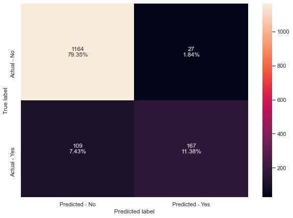

```python
make_confusion_matrix(bagging_estimator,y_test)
```

### Random Forest Classifier

```python
#Train the random forest classifier
rf_estimator=RandomForestClassifier(random_state=1)
rf_estimator.fit(X_train,y_train)
```

```
RandomForestClassifier(random_state=1)
```

```python
#Using above defined function to get accuracy, recall and precision on train and test set
rf_estimator_score=get_metrics_score(rf_estimator)
```

```
Accuracy on training set :  1.0
Accuracy on test set :  0.9154737559645535
Recall on training set :  1.0
Recall on test set :  0.6014492753623188
Precision on training set :  1.0
Precision on test set :  0.9222222222222223
```

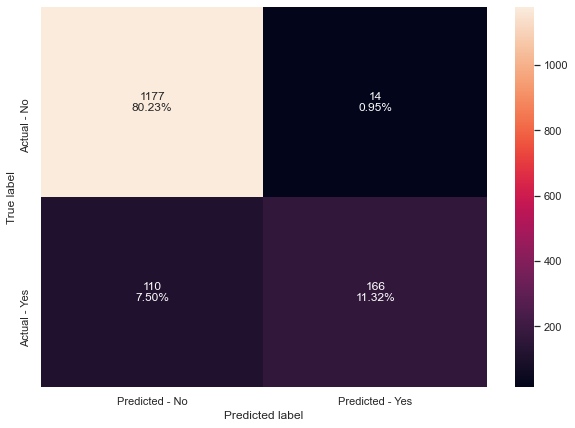

```python
make_confusion_matrix(rf_estimator,y_test)
```

**Insights with default parameters:**

- Both models - Bagging classifiers as well as random forest classifier are overfitting the train data.Random forest is more overfitting
- Both models are giving close to performance in terms of accuracy but bagging classifier is giving better recall.

## Hyperparameter Tuning

### Bagging Classifier

- We will be tuning the following Hyper parameters
- n_estimators: The number of trees in the forest, default = 100.
- max_features: The number of features to consider when looking for the best split.
- max_samples: If bootstrap is True, then the number of samples to draw from X to train each base estimator. If None (default), then draw N samples, where N is the number of observations in the train data.

```python
# Choose the type of classifier.
bagging_estimator_tuned = BaggingClassifier(random_state=1)

# Grid of parameters to choose from
## add from article
parameters = {'max_samples': [0.7,0.8,0.9,1],
              'max_features': [0.7,0.8,0.9,1],
              'n_estimators' : [10,20,30,40,50],
             }

# Type of scoring used to compare parameter combinations
acc_scorer = metrics.make_scorer(metrics.recall_score)

# Run the grid search
grid_obj = GridSearchCV(bagging_estimator_tuned, parameters, scoring=acc_scorer,cv=5)
grid_obj = grid_obj.fit(X_train, y_train)

# Set the clf to the best combination of parameters
bagging_estimator_tuned = grid_obj.best_estimator_

# Fit the best algorithm to the data.
bagging_estimator_tuned.fit(X_train, y_train)
```

```
BaggingClassifier(max_features=0.9, max_samples=0.9, n_estimators=50,
                  random_state=1)
```

```python
#Using above defined function to get accuracy, recall and precision on train and test set
bagging_estimator_tuned_score=get_metrics_score(bagging_estimator_tuned)
```

```
Accuracy on training set :  0.9997076878105817
Accuracy on test set :  0.9216087252897068
Recall on training set :  0.9984472049689441
Recall on test set :  0.6304347826086957
Precision on training set :  1.0
Precision on test set :  0.93048128342246
```

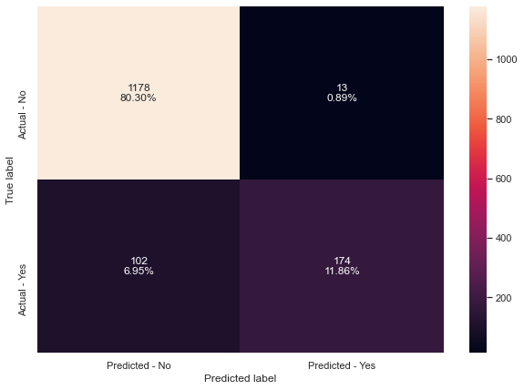

```python
make_confusion_matrix(bagging_estimator_tuned,y_test)
```

```python
bagging_lr=BaggingClassifier(base_estimator=LogisticRegression(random_state=1),random_state=1)
bagging_lr.fit(X_train,y_train)
```

```
BaggingClassifier(base_estimator=LogisticRegression(random_state=1),
                  random_state=1)
```

```python
#Using above defined function to get accuracy, recall and precision on train and test set
bagging_lr_score=get_metrics_score(bagging_lr)
```

```
Accuracy on training set :  0.8374744226834259
Accuracy on test set :  0.8336741649625086
Recall on training set :  0.20652173913043478
Recall on test set :  0.19202898550724637
Precision on training set :  0.7471910112359551
Precision on test set :  0.7162162162162162
```

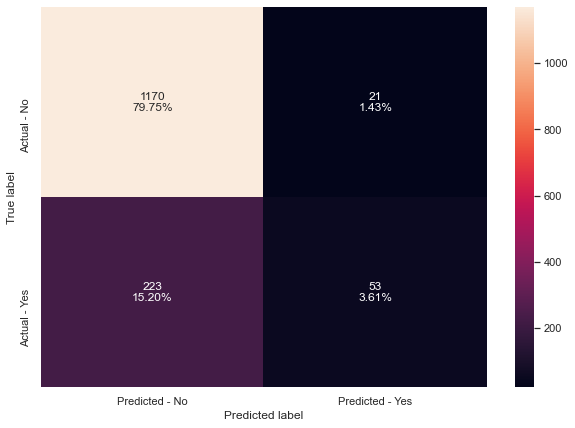

```python
make_confusion_matrix(bagging_lr,y_test)
```

### Random Forest Classifier

**Now, let's see if we can get a better model by tuning the random forest classifier. Some of the important hyperparameters available for random forest classifier are:**

- n_estimators: The number of trees in the forest, default = 100.
- max_features: The number of features to consider when looking for the best split.
- class_weight: Weights associated with classes in the form {class_label: weight}.If not given, all classes are supposed to have weight one.
- For example: If the frequency of class 0 is 80% and the frequency of class 1 is 20% in the data, then class 0 will become the dominant class and the model will become biased toward the dominant classes. In this case, we can pass a dictionary {0:0.2,1:0.8} to the model to specify the weight of each class and the random forest will give more weightage to class 1.
- bootstrap: Whether bootstrap samples are used when building trees. If False, the entire dataset is used to build each tree, default=True.
- max_samples: If bootstrap is True, then the number of samples to draw from X to train each base estimator. If None (default), then draw N samples, where N is the number of observations in the train data.
- oob_score: Whether to use out-of-bag samples to estimate the generalization accuracy, default=False.
- Note: A lot of hyperparameters of Decision Trees are also available to tune Random Forest like max_depth, min_sample_split etc.

```python
# Choose the type of classifier.
rf_estimator_tuned = RandomForestClassifier(random_state=1)

# Grid of parameters to choose from
## add from article
parameters = {"n_estimators": [150,200,250],
    "min_samples_leaf": np.arange(5, 10),
    "max_features": np.arange(0.2, 0.7, 0.1),
    "max_samples": np.arange(0.3, 0.7, 0.1),
             }

# Type of scoring used to compare parameter combinations
acc_scorer = metrics.make_scorer(metrics.recall_score)

# Run the grid search
grid_obj = GridSearchCV(rf_estimator_tuned, parameters, scoring=acc_scorer,cv=5)
grid_obj = grid_obj.fit(X_train, y_train)

# Set the clf to the best combination of parameters
rf_estimator_tuned = grid_obj.best_estimator_

# Fit the best algorithm to the data.
rf_estimator_tuned.fit(X_train, y_train)
```

```
RandomForestClassifier(max_features=0.6000000000000001,
                       max_samples=0.6000000000000001, min_samples_leaf=5,
                       n_estimators=250, random_state=1)
```

```python
#Using above defined function to get accuracy, recall and precision on train and test set
rf_estimator_tuned_score=get_metrics_score(rf_estimator_tuned)
```

```
Accuracy on training set :  0.907044723764981
Accuracy on test set :  0.8752556237218814
Recall on training set :  0.5341614906832298
Recall on test set :  0.40942028985507245
Precision on training set :  0.9502762430939227
Precision on test set :  0.849624060150376
```

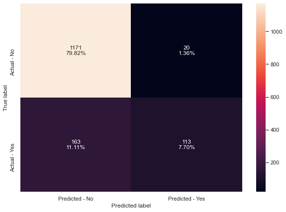

```python
make_confusion_matrix(rf_estimator_tuned,y_test)
```

- Random Forest with hyper tuned parameters is giving not as good a recall than the previous one.

## Boosting

### AdaBoost Classifier

```python
abc = AdaBoostClassifier(random_state=1)
abc.fit(X_train,y_train)
```

```
AdaBoostClassifier(random_state=1)
```

```python
#Using above defined function to get accuracy, recall and precision on train and test set
abc_score=get_metrics_score(abc)
```

```
Accuracy on training set :  0.8485822858813212
Accuracy on test set :  0.8507157464212679
Recall on training set :  0.32298136645962733
Recall on test set :  0.32971014492753625
Precision on training set :  0.7172413793103448
Precision on test set :  0.728
```

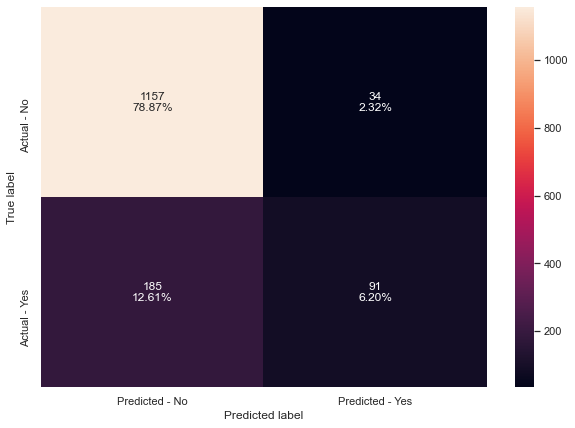

```python
make_confusion_matrix(abc,y_test)
```

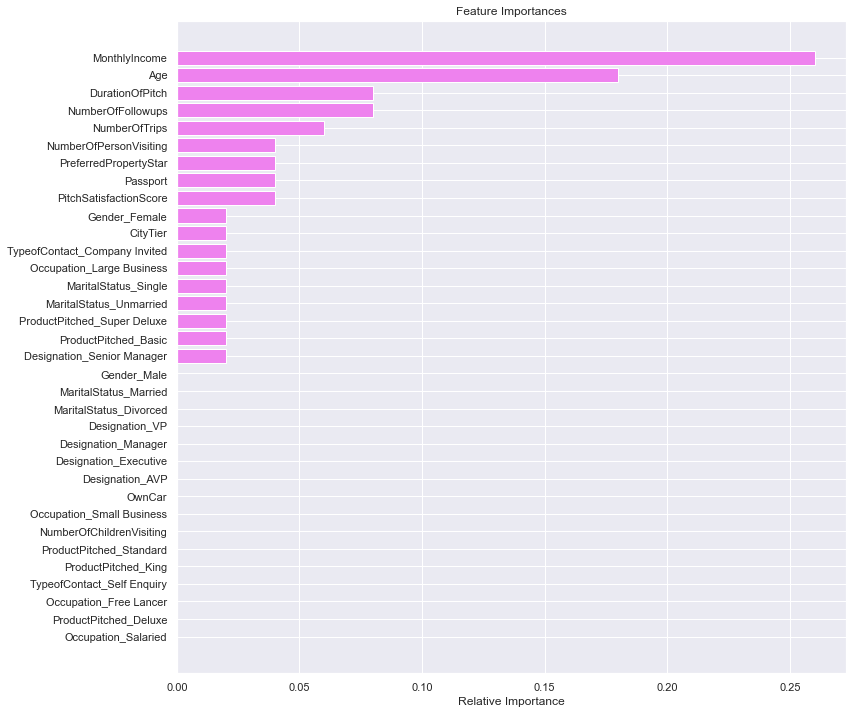

```python
importances = abc.feature_importances_
indices = np.argsort(importances)
feature_names = list(X.columns)

plt.figure(figsize=(12,12))
plt.title('Feature Importances')
plt.barh(range(len(indices)), importances[indices], color='violet', align='center')
plt.yticks(range(len(indices)), [feature_names[i] for i in indices])
plt.xlabel('Relative Importance')
plt.show()
```

### Insights

- Recall is low with AdaBoost classifier

### Gradient Boosting Classifier

```python
gbc = GradientBoostingClassifier(random_state=1)
gbc.fit(X_train,y_train)
```

```
GradientBoostingClassifier(random_state=1)
```

```python
#Using above defined function to get accuracy, recall and precision on train and test set
gbc_score=get_metrics_score(gbc)
```

```
Accuracy on training set :  0.8880444314527915
Accuracy on test set :  0.8725289706884799
Recall on training set :  0.4658385093167702
Recall on test set :  0.42028985507246375
Precision on training set :  0.8849557522123894
Precision on test set :  0.8111888111888111
```

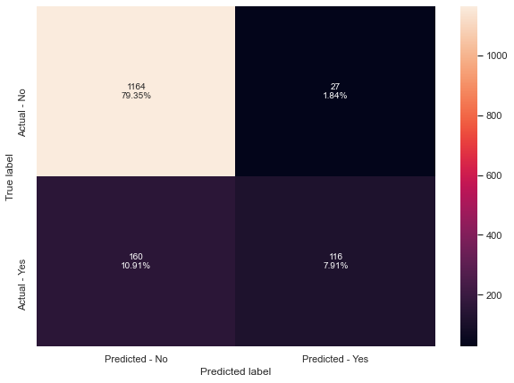

```python
make_confusion_matrix(gbc,y_test)
```

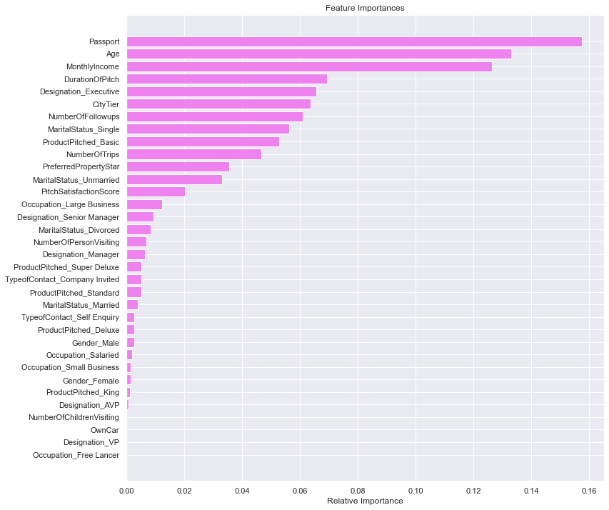

```python
importances = gbc.feature_importances_
indices = np.argsort(importances)
feature_names = list(X.columns)

plt.figure(figsize=(12,12))
plt.title('Feature Importances')
plt.barh(range(len(indices)), importances[indices], color='violet', align='center')
plt.yticks(range(len(indices)), [feature_names[i] for i in indices])
plt.xlabel('Relative Importance')
plt.show()
```

### Insights

- Recall is low with gradient boost classifier

### XGBoost Classifier

```python
xgb = XGBClassifier(random_state=1)
xgb.fit(X_train,y_train)
```

```
[16:47:06] WARNING: C:/Users/Administrator/workspace/xgboost-win64_release_1.4.0/src/learner.cc:1095: Starting in XGBoost 1.3.0, the default evaluation metric used with the objective 'binary:logistic' was changed from 'error' to 'logloss'. Explicitly set eval_metric if you'd like to restore the old …
```

```
XGBClassifier(base_score=0.5, booster='gbtree', colsample_bylevel=1,
              colsample_bynode=1, colsample_bytree=1, gamma=0, gpu_id=-1,
              importance_type='gain', interaction_constraints='',
              learning_rate=0.300000012, max_delta_step=0, max_depth=6,
              min_child_weight=1, missing=nan, monotone_constraints='()',
              n_estimators=100, n_jobs=4, num_parallel_tree=1, random_state=1,
              reg_alpha=0, reg_lambda=1, scale_pos_weight=1, subsample=1,
              tree_method='exact', validate_parameters=1, verbosity=None)
```

```python
#Using above defined function to get accuracy, recall and precision on train and test set
xgb_score=get_metrics_score(xgb)
```

```
Accuracy on training set :  0.9997076878105817
Accuracy on test set :  0.9250170415814588
Recall on training set :  0.9984472049689441
Recall on test set :  0.6884057971014492
Precision on training set :  1.0
Precision on test set :  0.8878504672897196
```

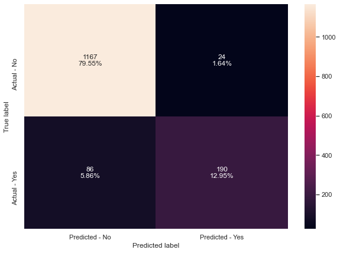

```python
make_confusion_matrix(xgb,y_test)
```

**Insights with default parameters:**

- Accuracy and Recall for XGBoost classifier is better than the other two.
- AdaBoost classifier has least test accuracy and test recall.

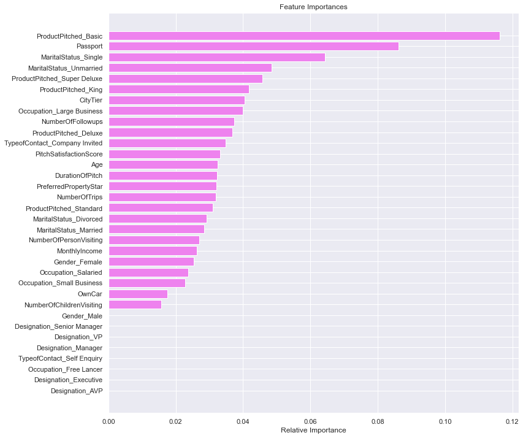

```python
importances = xgb.feature_importances_
indices = np.argsort(importances)
feature_names = list(X.columns)

plt.figure(figsize=(12,12))
plt.title('Feature Importances')
plt.barh(range(len(indices)), importances[indices], color='violet', align='center')
plt.yticks(range(len(indices)), [feature_names[i] for i in indices])
plt.xlabel('Relative Importance')
plt.show()
```

## Hyperparameter Tuning

### AdaBoost Classifier

```python
# Choose the type of classifier.
abc_tuned = AdaBoostClassifier(random_state=1)

# Grid of parameters to choose from
## add from article
parameters = {
    #Let's try different max_depth for base_estimator
    "base_estimator":[DecisionTreeClassifier(max_depth=1),DecisionTreeClassifier(max_depth=2),DecisionTreeClassifier(max_depth=3)],
    "n_estimators": np.arange(10,110,10),
    "learning_rate":np.arange(0.1,2,0.1)
}

# Type of scoring used to compare parameter combinations
acc_scorer = metrics.make_scorer(metrics.recall_score)

# Run the grid search
grid_obj = GridSearchCV(abc_tuned, parameters, scoring=acc_scorer,cv=5)
grid_obj = grid_obj.fit(X_train, y_train)

# Set the clf to the best combination of parameters
abc_tuned = grid_obj.best_estimator_

# Fit the best algorithm to the data.
abc_tuned.fit(X_train, y_train)
```

```
AdaBoostClassifier(base_estimator=DecisionTreeClassifier(max_depth=3),
                   learning_rate=1.7000000000000002, n_estimators=90,
                   random_state=1)
```

```python
#Using above defined function to get accuracy, recall and precision on train and test set
abc_tuned_score=get_metrics_score(abc_tuned)
```

```
Accuracy on training set :  0.9757380882782812
Accuracy on test set :  0.858214042263122
Recall on training set :  0.9145962732919255
Recall on test set :  0.5869565217391305
Precision on training set :  0.9546191247974068
Precision on test set :  0.6328125
```

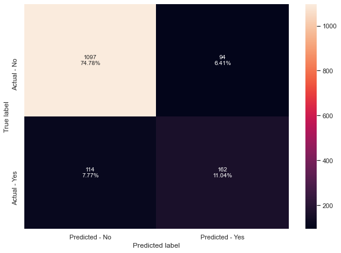

```python
make_confusion_matrix(abc_tuned,y_test)
```

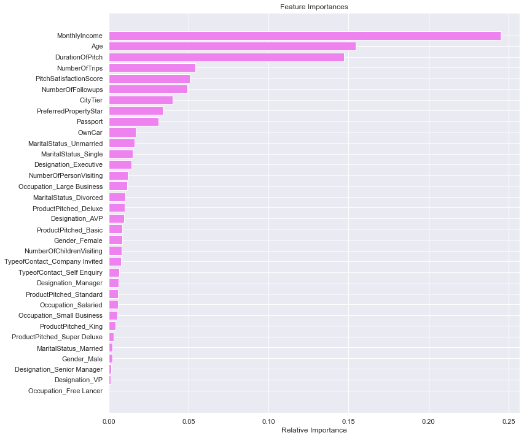

```python
importances = abc_tuned.feature_importances_
indices = np.argsort(importances)
feature_names = list(X.columns)

plt.figure(figsize=(12,12))
plt.title('Feature Importances')
plt.barh(range(len(indices)), importances[indices], color='violet', align='center')
plt.yticks(range(len(indices)), [feature_names[i] for i in indices])
plt.xlabel('Relative Importance')
plt.show()
```

- Using Hyper tuned Adaboost classifier the recall is better than without the hypertuning
- Monthly Income is the most important attribute followed by Age and Duration of pitch

### Gradient Boosting Classifier

```python
gbc_init = GradientBoostingClassifier(init=AdaBoostClassifier(random_state=1),random_state=1)
gbc_init.fit(X_train,y_train)
```

```
GradientBoostingClassifier(init=AdaBoostClassifier(random_state=1),
                           random_state=1)
```

```python
#Using above defined function to get accuracy, recall and precision on train and test set
gbc_init_score=get_metrics_score(gbc_init)
```

```
Accuracy on training set :  0.8877521192633733
Accuracy on test set :  0.869120654396728
Recall on training set :  0.4658385093167702
Recall on test set :  0.40217391304347827
Precision on training set :  0.8823529411764706
Precision on test set :  0.8043478260869565
```

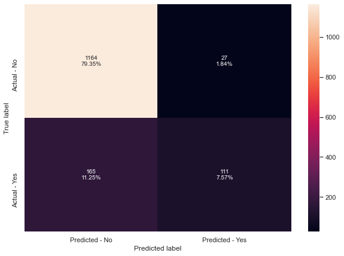

```python
make_confusion_matrix(gbc_init,y_test)
```

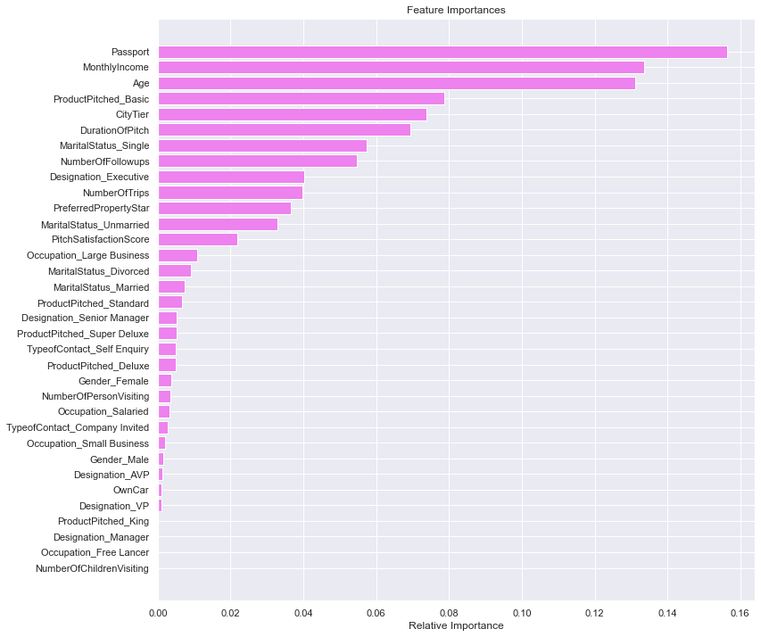

```python
importances = gbc_init.feature_importances_
indices = np.argsort(importances)
feature_names = list(X.columns)

plt.figure(figsize=(12,12))
plt.title('Feature Importances')
plt.barh(range(len(indices)), importances[indices], color='violet', align='center')
plt.yticks(range(len(indices)), [feature_names[i] for i in indices])
plt.xlabel('Relative Importance')
plt.show()
```

**Insights with default parameters:**

- Recall is low with gradient Boost with Adaboost classifier init.

```python
# Choose the type of classifier.
gbc_tuned = GradientBoostingClassifier(init=AdaBoostClassifier(random_state=1),random_state=1)

# Grid of parameters to choose from
## add from article
parameters = {
    "n_estimators": [100,150,200,250],
    "subsample":[0.8,0.9,1],
    "max_features":[0.7,0.8,0.9,1]
}

# Type of scoring used to compare parameter combinations
acc_scorer = metrics.make_scorer(metrics.recall_score)

# Run the grid search
grid_obj = GridSearchCV(gbc_tuned, parameters, scoring=acc_scorer,cv=5)
grid_obj = grid_obj.fit(X_train, y_train)

# Set the clf to the best combination of parameters
gbc_tuned = grid_obj.best_estimator_

# Fit the best algorithm to the data.
gbc_tuned.fit(X_train, y_train)
```

```
GradientBoostingClassifier(init=AdaBoostClassifier(random_state=1),
                           max_features=0.9, n_estimators=250, random_state=1,
                           subsample=0.9)
```

```python
#Using above defined function to get accuracy, recall and precision on train and test set
gbc_tuned_score=get_metrics_score(gbc_tuned)
```

```
Accuracy on training set :  0.9234142063724057
Accuracy on test set :  0.885480572597137
Recall on training set :  0.6257763975155279
Recall on test set :  0.5072463768115942
Precision on training set :  0.9504716981132075
Precision on test set :  0.813953488372093
```

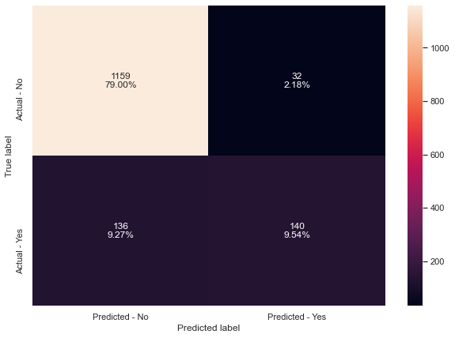

```python
make_confusion_matrix(gbc_tuned,y_test)
```

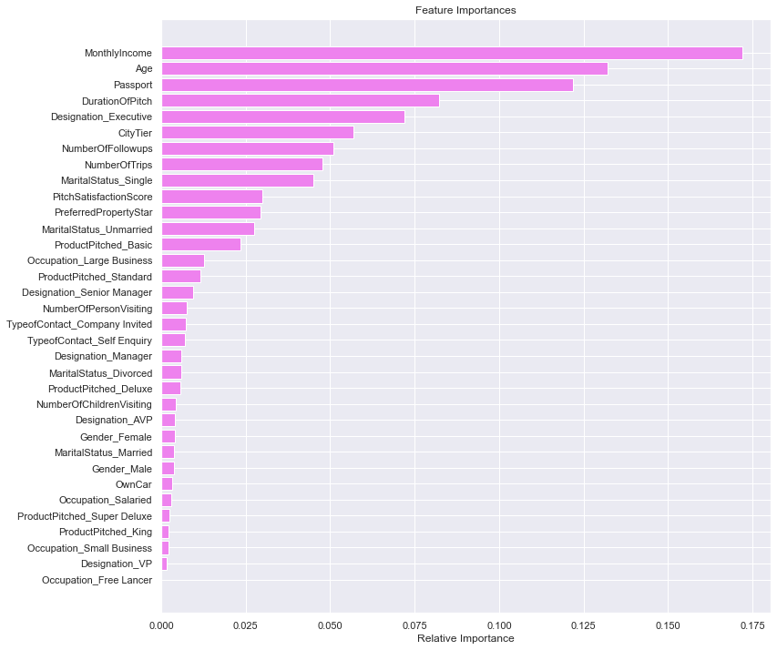

```python
importances = gbc_tuned.feature_importances_
indices = np.argsort(importances)
feature_names = list(X.columns)

plt.figure(figsize=(12,12))
plt.title('Feature Importances')
plt.barh(range(len(indices)), importances[indices], color='violet', align='center')
plt.yticks(range(len(indices)), [feature_names[i] for i in indices])
plt.xlabel('Relative Importance')
plt.show()
```

- Tuned gradient Boosting model has a better recall than untuned one.

### XGBoost Classifier Hyperparameters tuning

```python
# Choose the type of classifier.
xgb_tuned = XGBClassifier(random_state=1,eval_metric='logloss')

# Grid of parameters to choose from
## add from
parameters = {
    "n_estimators": np.arange(10,30,20),
    "scale_pos_weight":[0,1,2,5],
    "subsample":[0.5,0.7,0.9,1],
    "learning_rate":[0.01,0.1,0.2,0.05],
    "gamma":[0,1,3],
    "colsample_bytree":[0.5,0.7,0.9,1],
    "colsample_bylevel":[0.5,0.7,0.9,1]
}

# Type of scoring used to compare parameter combinations
acc_scorer = metrics.make_scorer(metrics.recall_score)

# Run the grid search
grid_obj = GridSearchCV(xgb_tuned, parameters,scoring=acc_scorer,cv=5)
grid_obj = grid_obj.fit(X_train, y_train)

# Set the clf to the best combination of parameters
xgb_tuned = grid_obj.best_estimator_

# Fit the best algorithm to the data.
xgb_tuned.fit(X_train, y_train)
```

```
XGBClassifier(base_score=0.5, booster='gbtree', colsample_bylevel=0.9,
              colsample_bynode=1, colsample_bytree=0.5, eval_metric='logloss',
              gamma=3, gpu_id=-1, importance_type='gain',
              interaction_constraints='', learning_rate=0.2, max_delta_step=0,
              max_depth=6, min_child_weight=1, missing=nan,
              monotone_constraints='()', n_estimators=10, n_jobs=4,
              num_parallel_tree=1, random_state=1, reg_alpha=0, reg_lambda=1,
              scale_pos_weight=5, subsample=1, tree_method='exact',
              validate_parameters=1, verbosity=None)
```

```python
#Using above defined function to get accuracy, recall and precision on train and test set
xgb_tuned_score=get_metrics_score(xgb_tuned)
```

```
Accuracy on training set :  0.8640748319204911
Accuracy on test set :  0.825494205862304
Recall on training set :  0.906832298136646
Recall on test set :  0.8333333333333334
Precision on training set :  0.5904954499494439
Precision on test set :  0.5227272727272727
```

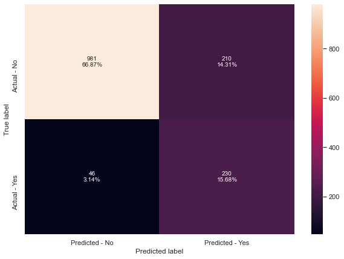

```python
make_confusion_matrix(xgb_tuned,y_test)
```

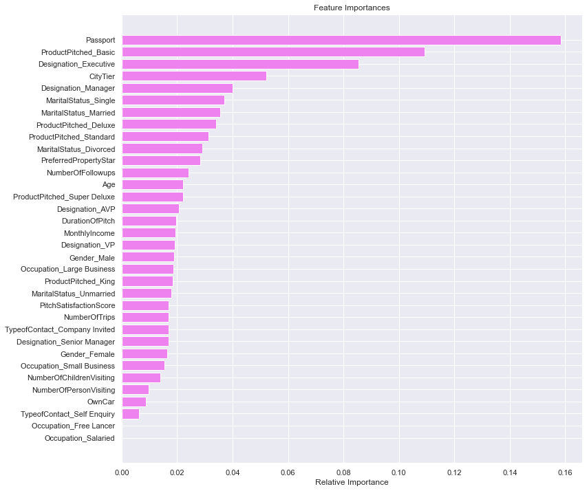

```python
importances = xgb_tuned.feature_importances_
indices = np.argsort(importances)
feature_names = list(X.columns)

plt.figure(figsize=(12,12))
plt.title('Feature Importances')
plt.barh(range(len(indices)), importances[indices], color='violet', align='center')
plt.yticks(range(len(indices)), [feature_names[i] for i in indices])
plt.xlabel('Relative Importance')
plt.show()
```

**Insights :**

- Recall is by far the best on testing data.
- Accuracy is fair on both training and testing data.
- Precision is a bit low on training and testing data.

## Decision Tree Model

```python
dTree = DecisionTreeClassifier(criterion = 'gini', random_state=1)
dTree.fit(X_train, y_train)
```

```
DecisionTreeClassifier(random_state=1)
```

```python
##  Function to calculate recall score
def get_recall_score(model):
    '''
    model : classifier to predict values of X

    '''
    pred_train = model.predict(X_train)
    pred_test = model.predict(X_test)
    print("Recall on training set : ",metrics.recall_score(y_train,pred_train))
    print("Recall on test set : ",metrics.recall_score(y_test,pred_test))
```

```python
##  Function to calculate recall score
def get_recall_score(model):
    '''
    model : classifier to predict values of X

    '''
    pred_train = model.predict(X_train)
    pred_test = model.predict(X_test)
    print("Recall on training set : ",metrics.recall_score(y_train,pred_train))
    print("Recall on test set : ",metrics.recall_score(y_test,pred_test))
```

```python
# Recall on train and test
dTree_score=get_metrics_score(dTree)
```

```
Accuracy on training set :  1.0
Accuracy on test set :  0.8936605316973415
Recall on training set :  1.0
Recall on test set :  0.6739130434782609
Precision on training set :  1.0
Precision on test set :  0.7380952380952381
```

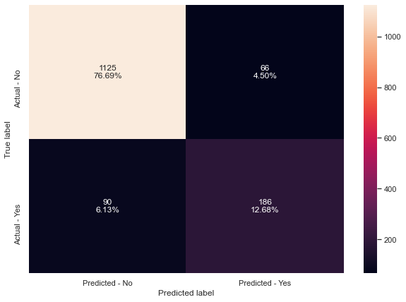

```python
make_confusion_matrix(dTree,y_test)
```

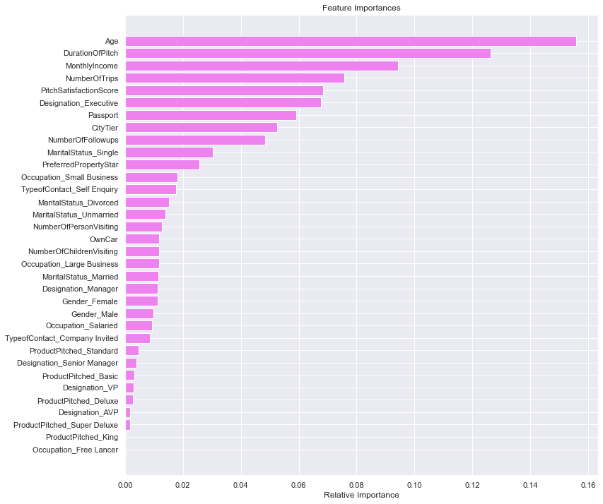

```python
importances = dTree.feature_importances_
indices = np.argsort(importances)

plt.figure(figsize=(12,12))
plt.title('Feature Importances')
plt.barh(range(len(indices)), importances[indices], color='violet', align='center')
plt.yticks(range(len(indices)), [feature_names[i] for i in indices])
plt.xlabel('Relative Importance')
plt.show()
```

**Insights :**

- The accuracy, recall and precision on training set is 1 which clearly shows overfitting.

## Hyperparameter tuning of Decision Tree

```python
# Choose the type of classifier.
estimator = DecisionTreeClassifier(random_state=1)

# Grid of parameters to choose from
## add from article
parameters = {'max_depth': np.arange(1,10),
              'min_samples_leaf': [1, 2, 5, 7, 10,15,20],
              'max_leaf_nodes' : [2, 3, 5, 10],
              'min_impurity_decrease': [0.001,0.01,0.1]
             }

# Type of scoring used to compare parameter combinations
acc_scorer = metrics.make_scorer(metrics.recall_score)

# Run the grid search
grid_obj = GridSearchCV(estimator, parameters, scoring=acc_scorer,cv=5)
grid_obj = grid_obj.fit(X_train, y_train)

# Set the clf to the best combination of parameters
estimator = grid_obj.best_estimator_

# Fit the best algorithm to the data.
estimator.fit(X_train, y_train)
```

```
DecisionTreeClassifier(max_depth=2, max_leaf_nodes=3,
                       min_impurity_decrease=0.001, random_state=1)
```

```python
# Accuracy on train and test
print("Accuracy on training set : ",estimator.score(X_train, y_train))
print("Accuracy on test set : ",estimator.score(X_test, y_test))
# Recall on train and test
get_recall_score(estimator)
```

```
Accuracy on training set :  0.8213972522654195
Accuracy on test set :  0.8411724608043627
Recall on training set :  0.3416149068322981
Recall on test set :  0.3695652173913043
```

- Recall on training and testing set is way poorer with Hyper tuning

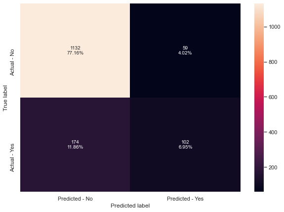

```python
make_confusion_matrix(estimator,y_test)
```

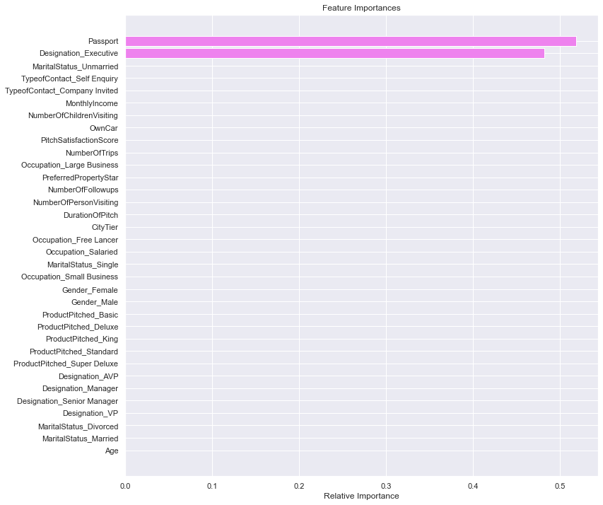

```python
importances = estimator.feature_importances_
indices = np.argsort(importances)

plt.figure(figsize=(12,12))
plt.title('Feature Importances')
plt.barh(range(len(indices)), importances[indices], color='violet', align='center')
plt.yticks(range(len(indices)), [feature_names[i] for i in indices])
plt.xlabel('Relative Importance')
plt.show()
```

**Insights :**

- The recall is too low on the training and testing data.

## Stacking Model

**Stacking model with the tuned models - decision tree, random forest and gradient boosting, then use XGBoost to get the final prediction.**

```python
estimators=[('Decision Tree', estimator),('Random Forest', rf_estimator_tuned),
           ('Gradient Boosting', gbc_tuned)]
final_estimator=XGBClassifier(random_state=1)
```

```python
stacking_estimator=StackingClassifier(estimators=estimators, final_estimator=final_estimator,cv=5)
stacking_estimator.fit(X_train,y_train)
```

```
[18:37:22] WARNING: C:/Users/Administrator/workspace/xgboost-win64_release_1.4.0/src/learner.cc:1095: Starting in XGBoost 1.3.0, the default evaluation metric used with the objective 'binary:logistic' was changed from 'error' to 'logloss'. Explicitly set eval_metric if you'd like to restore the old …
```

```
StackingClassifier(cv=5,
                   estimators=[('Decision Tree',
                                DecisionTreeClassifier(max_depth=2,
                                                       max_leaf_nodes=3,
                                                       min_impurity_decrease=0.001,
                                                       random_state=1)),
                               ('Random Forest',
                                RandomForestClassifier(max_features=0.6000000000000001,
                                                       max_samples=0.6000000000000001,
                                                       min_samples_leaf=5,
                                                       n_estimators=250,
                                                       random_state=1)),
                               ('Gradient Boosting',
                                GradientBoostingClassifier...
                                                 importance_type='gain',
                                                 interaction_constraints=None,
                                                 learning_rate=None,
                                                 max_delta_step=None,
                                                 max_depth=None,
                                                 min_child_weight=None,
                                                 missing=nan,
                                                 monotone_constraints=None,
                                                 n_estimators=100, n_jobs=None,
                                                 num_parallel_tree=None,
                                                 random_state=1, reg_alpha=None,
                                                 reg_lambda=None,
                                                 scale_pos_weight=None,
                                                 subsample=None,
                                                 tree_method=None,
                                                 validate_parameters=None,
                                                 verbosity=None))
```

```python
stacking_estimator_score=get_metrics_score(stacking_estimator)
```

```
Accuracy on training set :  0.9219526454253142
Accuracy on test set :  0.8759372869802318
Recall on training set :  0.6894409937888198
Recall on test set :  0.5398550724637681
Precision on training set :  0.8688845401174168
Precision on test set :  0.7303921568627451
```

**Insights :**

- The recall is fair even though the accuracy is good.
- Precision is also good.

## Comparing all models

```python
# defining list of models
models = [bagging_estimator,rf_estimator,bagging_estimator_tuned,rf_estimator_tuned,abc,gbc,xgb,abc_tuned,gbc_init,gbc_tuned,xgb_tuned,dTree,estimator,stacking_estimator]

# defining empty lists to add train and test results
acc_train = []
acc_test = []
recall_train = []
recall_test = []
precision_train = []
precision_test = []

# looping through all the models to get the accuracy, precall and precision scores
for model in models:
    j = get_metrics_score(model,False)
    acc_train.append(np.round(j[0],2))
    acc_test.append(np.round(j[1],2))
    recall_train.append(np.round(j[2],2))
    recall_test.append(np.round(j[3],2))
    precision_train.append(np.round(j[4],2))
    precision_test.append(np.round(j[5],2))
```

```python
comparison_frame = pd.DataFrame({'Model':['Bagging Classifier','Random Forest Classifier','Bagging Classifier Tuned','Random Forest Classifier Tuned','AdaBoost with default parameters','Gradient Boost Classifier  default parameters','XGBoost Classifier default params','AdaBoost Tuned',
                                          'Gradient Boosting with init=AdaBoost',
                                          'Gradient Boosting Tuned','XGBoost Tuned','Descision Tree','Decision Tree Tuned','Stacking'],
                                          'Train_Accuracy': acc_train,'Test_Accuracy': acc_test,
                                          'Train_Recall':recall_train,'Test_Recall':recall_test,
                                          'Train_Precision':precision_train,'Test_Precision':precision_test})
comparison_frame
```

|  | Model | Train_Accuracy | Test_Accuracy | Train_Recall | Test_Recall | Train_Precision | Test_Precision |
| --- | --- | --- | --- | --- | --- | --- | --- |
| 0 | Bagging Classifier | 0.99 | 0.91 | 0.96 | 0.61 | 1.00 | 0.86 |
| 1 | Random Forest Classifier | 1.00 | 0.92 | 1.00 | 0.60 | 1.00 | 0.92 |
| 2 | Bagging Classifier Tuned | 1.00 | 0.92 | 1.00 | 0.63 | 1.00 | 0.93 |
| 3 | Random Forest Classifier Tuned | 0.91 | 0.88 | 0.53 | 0.41 | 0.95 | 0.85 |
| 4 | AdaBoost with default parameters | 0.85 | 0.85 | 0.32 | 0.33 | 0.72 | 0.73 |
| 5 | Gradient Boost Classifier default parameters | 0.89 | 0.87 | 0.47 | 0.42 | 0.88 | 0.81 |
| 6 | XGBoost Classifier default params | 1.00 | 0.93 | 1.00 | 0.69 | 1.00 | 0.89 |
| 7 | AdaBoost Tuned | 0.98 | 0.86 | 0.91 | 0.59 | 0.95 | 0.63 |
| 8 | Gradient Boosting with init=AdaBoost | 0.89 | 0.87 | 0.47 | 0.40 | 0.88 | 0.80 |
| 9 | Gradient Boosting Tuned | 0.92 | 0.89 | 0.63 | 0.51 | 0.95 | 0.81 |
| 10 | XGBoost Tuned | 0.86 | 0.83 | 0.91 | 0.83 | 0.59 | 0.52 |
| 11 | Descision Tree | 1.00 | 0.89 | 1.00 | 0.67 | 1.00 | 0.74 |
| 12 | Decision Tree Tuned | 0.82 | 0.84 | 0.34 | 0.37 | 0.54 | 0.63 |
| 13 | Stacking | 0.92 | 0.88 | 0.69 | 0.54 | 0.87 | 0.73 |

## Business Recommendations

- As seen from most of the models the most important things for customers taking the product are the one's who have the passport.The company should try to focus more on people having passports as they do not have any restrictions to travel internationally also.
- The second important thing is monthly income. Income have a postive correlation with decision to take the product. The company must focus on selling Basic product to customers in the lowest income range customers. They should focus on customers with slightly higher income range to take deluxe product.Basically customers with monthly income range till 25000 should be focused for basic and Deluxe. They should focus on the highest income range individuals for King product , income range > 35000 followed by Super deluxe and standard product for income ranges between 25000- 35000
- Age has a negative corrrelation with the package been sold, so the focus should be more on younger people.
- The class of customers taking the product most is Executive class followed by managers/senior managers and large businesses The focus should be on these classes.
- The package is been sold a bit more in males as compared to females.
- The marketing should focus on customers from tier2 and tier3 cities more than tier1 city customers.
- In general they should try to sell Basic and Standard more based on previous experience.
- They should focus on single people more than married or divorced people.
- They should focus more on higher sales pitch satisfaction score.
- They should focus more on the customers who had 2-3 people visiting.
- For Basic, Deluxe and King they should have followups between 3-5 atleast whereas for super deluxe 3 followups should be ok.